# DATA606 - Summarizing Data

September 2, 2020

## Summarizing Data

```r
devtools::install_github("seankross/lego")
```

```r
library(lego)
data(legosets)
```

## Types of Variables

- Numerical (quantitative)
  - Continuous
  - Discrete
- Categorical (qualitative)
  - Regular categorical
  - Ordinal

## Data Types in R

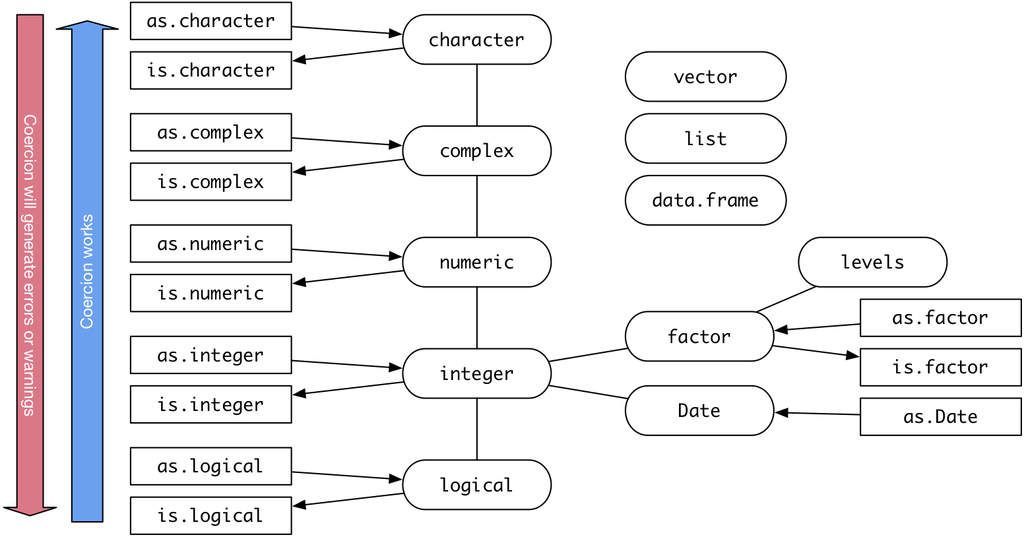

## Types of Variables

```r
str(legosets)
```

```
## Classes 'tbl_df', 'tbl' and 'data.frame':    6172 obs. of  14 variables:
##  $ Item_Number : chr  "10246" "10247" "10248" "10249" ...
##  $ Name        : chr  "Detective's Office" "Ferris Wheel" "Ferrari F40" "Toy Shop" ...
##  $ Year        : int  2015 2015 2015 2015 2015 2015 2015 2015 2015 2015 ...
##  $ Theme       : chr  "Advanced Models" "Advanced Models" "Advanced Models" "Advanced Models" ...
##  $ Subtheme    : chr  "Modular Buildings" "Fairground" "Vehicles" "Winter Village" ...
##  $ Pieces      : int  2262 2464 1158 898 13 39 32 105 13 11 ...
##  $ Minifigures : int  6 10 NA NA 1 2 2 3 2 2 ...
##  $ Image_URL   : chr  "http://images.brickset.com/sets/images/10246-1.jpg" "http://images.brickset.com/sets/images/10247-1.jpg" "http://images.brickset.com/sets/images/10248-1.jpg" "http://images.brickset.com/sets/images/10249-1.jpg" ...
##  $ GBP_MSRP    : num  132.99 149.99 69.99 59.99 9.99 ...
##  $ USD_MSRP    : num  159.99 199.99 99.99 79.99 9.99 ...
##  $ CAD_MSRP    : num  200 230 120 NA 13 ...
##  $ EUR_MSRP    : num  149.99 179.99 89.99 69.99 9.99 ...
##  $ Packaging   : chr  "Box" "Box" "Box" "Box" ...
##  $ Availability: chr  "Retail - limited" "Retail - limited" "LEGO exclusive" "LEGO exclusive" ...
```

## Qualitative Variables

Descriptive statistics:

- Contingency Tables
- Proportional Tables

Plot types:

- Bar plot

## Contingency Tables

```r
table(legosets$Availability, useNA='ifany')
```

```
##
##        LEGO exclusive    LEGOLAND exclusive         Not specified
##                   695                     2                  1795
##           Promotional Promotional (Airline)                Retail
##                   141                    12                  3120
##      Retail - limited               Unknown
##                   403                     4
```

```r
table(legosets$Availability, legosets$Packaging, useNA='ifany')
```

```
##
##                         Blister pack  Box Box with backing card Bucket Canister
##   LEGO exclusive                  45  147                     0      1        0
##   LEGOLAND exclusive               0    2                     0      0        0
##   Not specified                    0   20                     0      0        0
##   Promotional                      0   44                     0      0        0
##   Promotional (Airline)            0   11                     0      0        0
##   Retail                          53 2575                    16     30       78
##   Retail - limited                 2  302                     1      5        0
##   Unknown                          0    1                     0      0        0
##
##                         Foil pack Loose Parts Not specified Other Plastic box
##   LEGO exclusive                0          71             7     5           1
##   LEGOLAND exclusive            0           0             0     0           0
##   Not specified                 5           0          1739     0           6
##   Promotional                   0           1             0     3           2
##   Promotional (Airline)         0           0             1     0           0
##   Retail                      285           0             0    28           0
##   Retail - limited              1           0             0     0           1
##   Unknown                       0           0             0     0           0
##
##                         Polybag Shrink-wrapped  Tag  Tub
##   LEGO exclusive            412              0    6    0
##   LEGOLAND exclusive          0              0    0    0
##   Not specified              24              0    0    1
##   Promotional                90              0    0    1
##   Promotional (Airline)       0              0    0    0
##   Retail                      4             18    0   33
##   Retail - limited           86              0    0    5
##   Unknown                     3              0    0    0
```

## Proportional Tables

```r
prop.table(table(legosets$Availability))
```

```
##
##        LEGO exclusive    LEGOLAND exclusive         Not specified
##          0.1126053143          0.0003240441          0.2908295528
##           Promotional Promotional (Airline)                Retail
##          0.0228451069          0.0019442644          0.5055087492
##      Retail - limited               Unknown
##          0.0652948801          0.0006480881
```

## Bar Plots

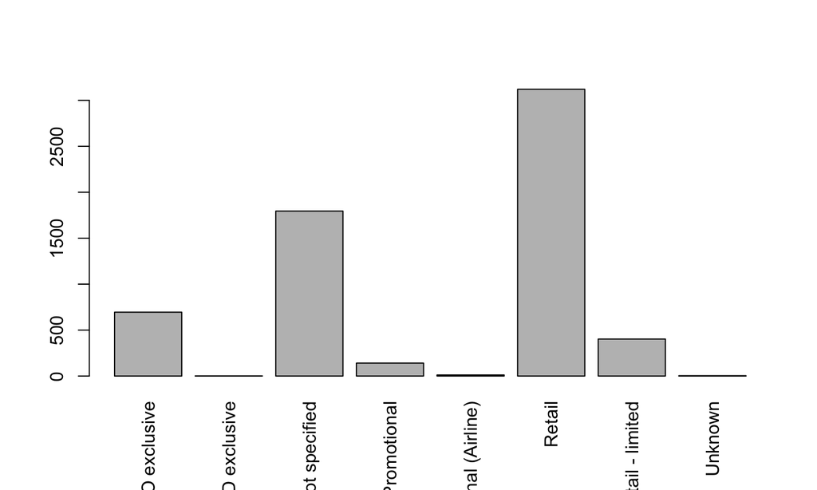

```r
barplot(table(legosets$Availability), las=3)
```

## Bar Plots

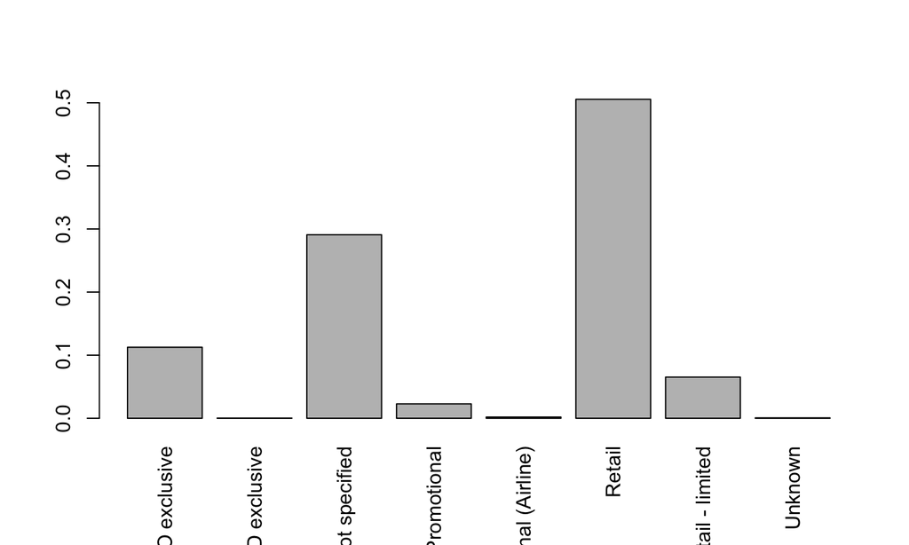

```r
barplot(prop.table(table(legosets$Availability)), las=3)
```

## Quantitative Variables

Descriptive statistics:

- Mean
- Median
- Quartiles
- Variance: \({ s }^{ 2 }=\sum _{ i=1 }^{ n }{ \frac { { \left( { x }_{ i }-\bar { x } \right) }^{ 2 } }{ n-1 } }\)
- Standard deviation: \(s=\sqrt{s^2}\)

Plot types:

- Dot plots
- Histograms
- Density plots
- Box plots
- Scatterplots

## Measures of Center

```r
mean(legosets$Pieces, na.rm=TRUE)
```

```
## [1] 215.1686
```

```r
median(legosets$Pieces, na.rm=TRUE)
```

```
## [1] 82
```

## Measures of Spread

```r
var(legosets$Pieces, na.rm=TRUE)
```

```
## [1] 126876.8
```

```r
sqrt(var(legosets$Pieces, na.rm=TRUE))
```

```
## [1] 356.1976
```

```r
sd(legosets$Pieces, na.rm=TRUE)
```

```
## [1] 356.1976
```

```r
fivenum(legosets$Pieces, na.rm=TRUE)
```

```
## [1]    0.0   30.0   82.0  256.5 5922.0
```

```r
IQR(legosets$Pieces, na.rm=TRUE)
```

```
## [1] 226.25
```

## The `summary` Function

```r
summary(legosets$Pieces)
```

```
##    Min. 1st Qu.  Median    Mean 3rd Qu.    Max.    NA's
##     0.0    30.0    82.0   215.2   256.2  5922.0     112
```

## The `psych` Package

```r
library(psych)
describe(legosets$Pieces, skew=FALSE)
```

```
##    vars    n   mean    sd min  max range   se
## X1    1 6060 215.17 356.2   0 5922  5922 4.58
```

```r
describeBy(legosets$Pieces, group = legosets$Availability, skew=FALSE, mat=TRUE)
```

```
##     item                group1 vars    n      mean        sd min  max range
## X11    1        LEGO exclusive    1  659 172.74203 442.96954   1 3428  3427
## X12    2    LEGOLAND exclusive    1    2 211.00000 154.14928 102  320   218
## X13    3         Not specified    1 1747 145.87178 309.19929   1 5195  5194
## X14    4           Promotional    1  140  53.97143 108.42721   1 1000   999
## X15    5 Promotional (Airline)    1   12 126.16667  47.01612  10  203   193
## X16    6                Retail    1 3094 245.78119 294.78052   0 3803  3803
## X17    7      Retail - limited    1  402 410.94030 652.06435   1 5922  5921
## X18    8               Unknown    1    4  27.50000  15.96872   6   44    38
##             se
## X11  17.255643
## X12 109.000000
## X13   7.397620
## X14   9.163772
## X15  13.572384
## X16   5.299546
## X17  32.522014
## X18   7.984360
```

## Robust Statistics

Median and IQR are more robust to skewness and outliers than mean and SD. Therefore,

- for skewed distributions it is often more helpful to use median and IQR to describe the center and spread
- for symmetric distributions it is often more helpful to use the mean and SD to describe the center and spread

## Dot Plot

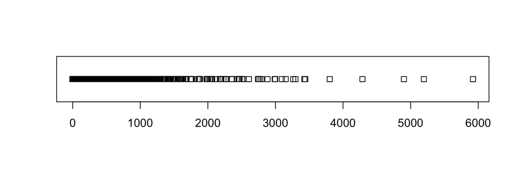

```r
stripchart(legosets$Pieces)
```

## Dot Plot

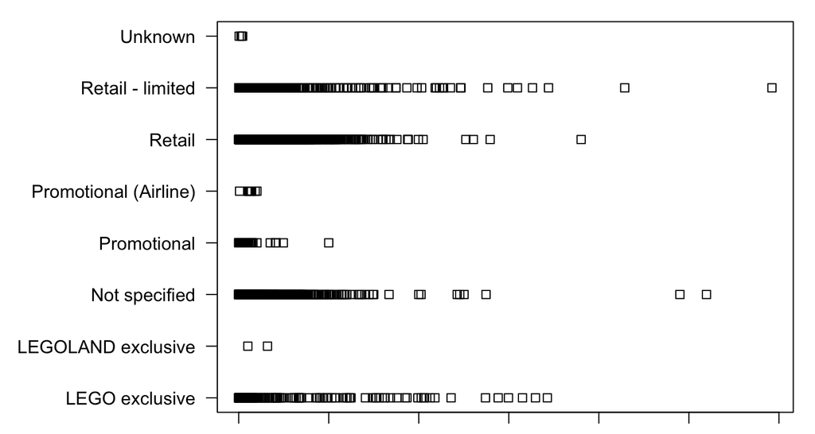

```r
par.orig <- par(mar=c(1,10,1,1))
stripchart(legosets$Pieces ~ legosets$Availability, las=1)
```

```r
par(par.orig)
```

## Histograms

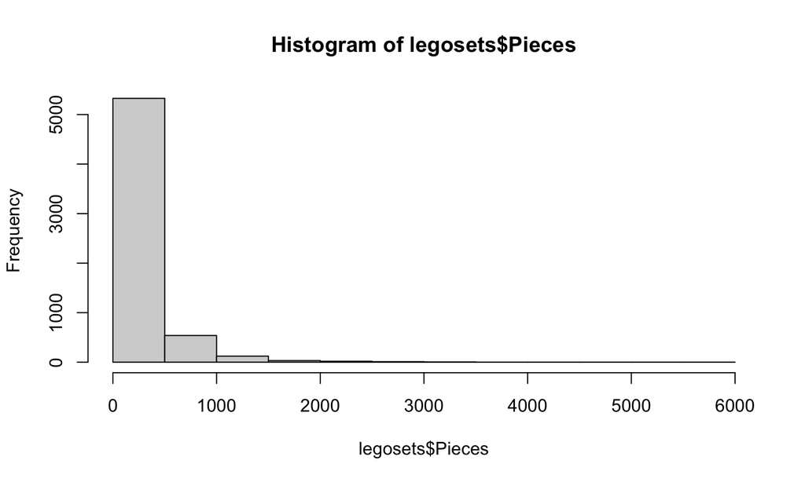

```r
hist(legosets$Pieces)
```

## Transformations

With highly skewed distributions, it is often helpful to transform the data. The log transformation is a common approach, especially when dealing with salary or similar data.

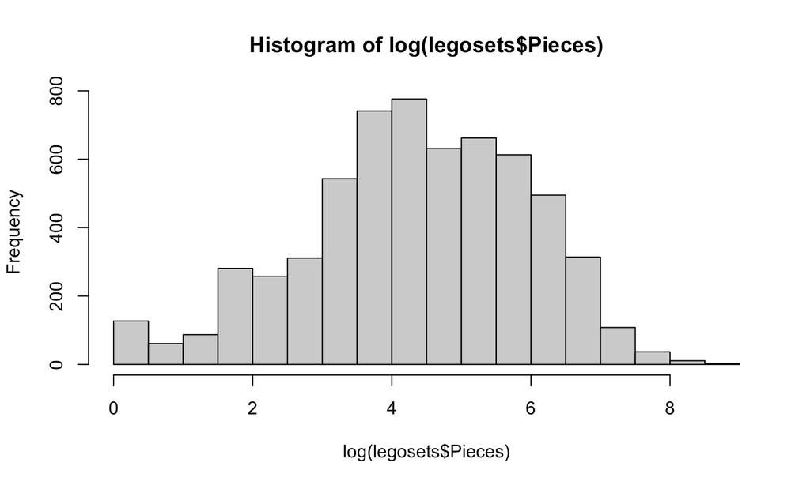

```r
hist(log(legosets$Pieces))
```

## Density Plots

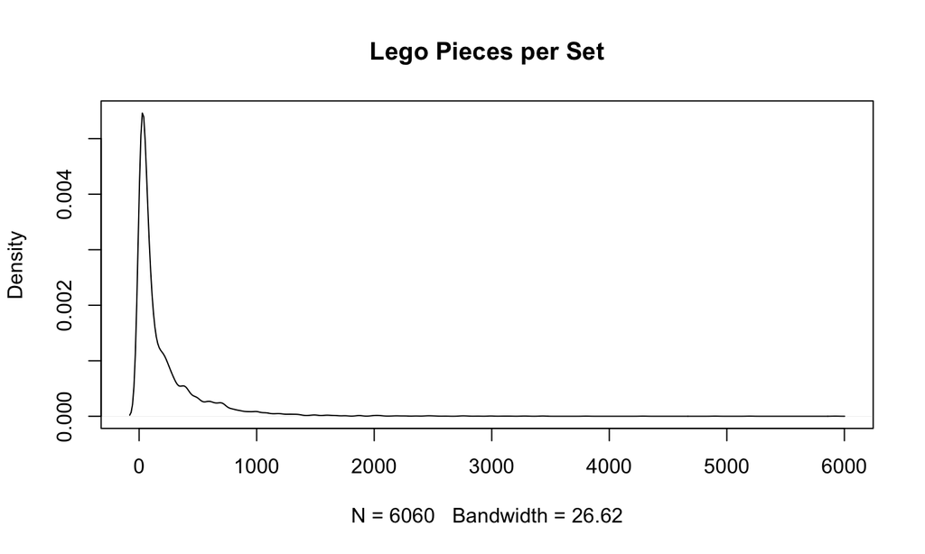

```r
plot(density(legosets$Pieces, na.rm=TRUE), main='Lego Pieces per Set')
```

## Density Plot (log tansformed)

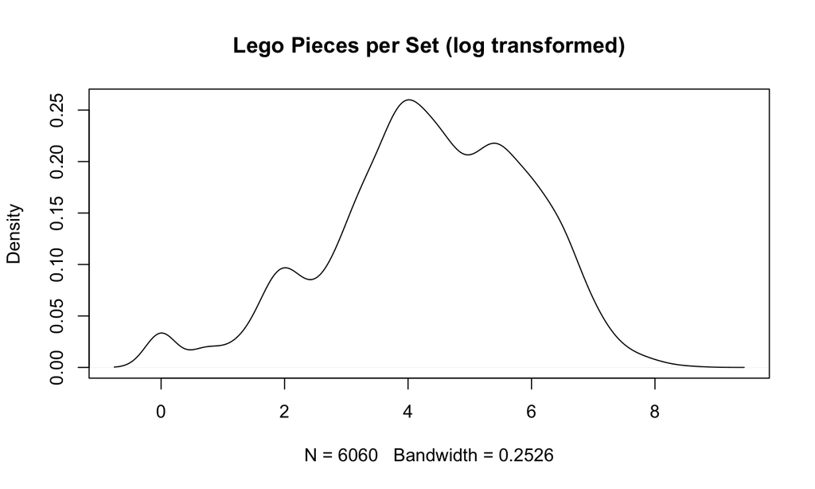

```r
plot(density(log(legosets$Pieces), na.rm=TRUE), main='Lego Pieces per Set (log transformed)')
```

## Box Plots

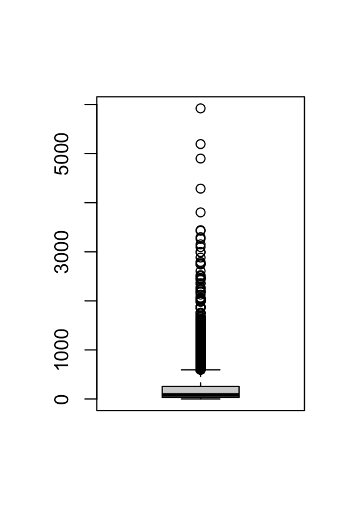

```r
boxplot(legosets$Pieces)
```

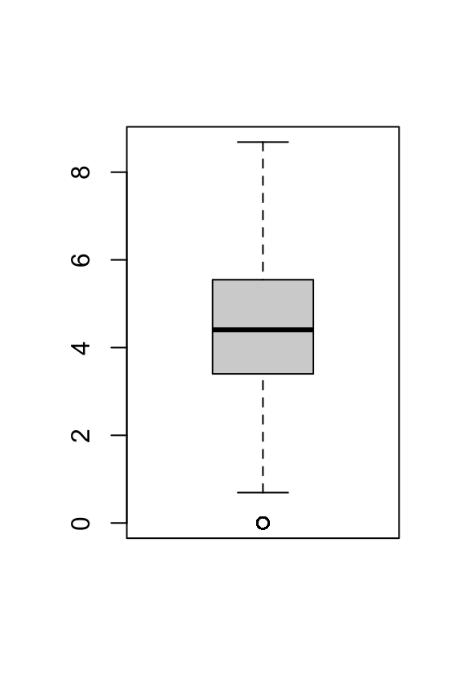

```r
boxplot(log(legosets$Pieces))
```

## Scatter Plots

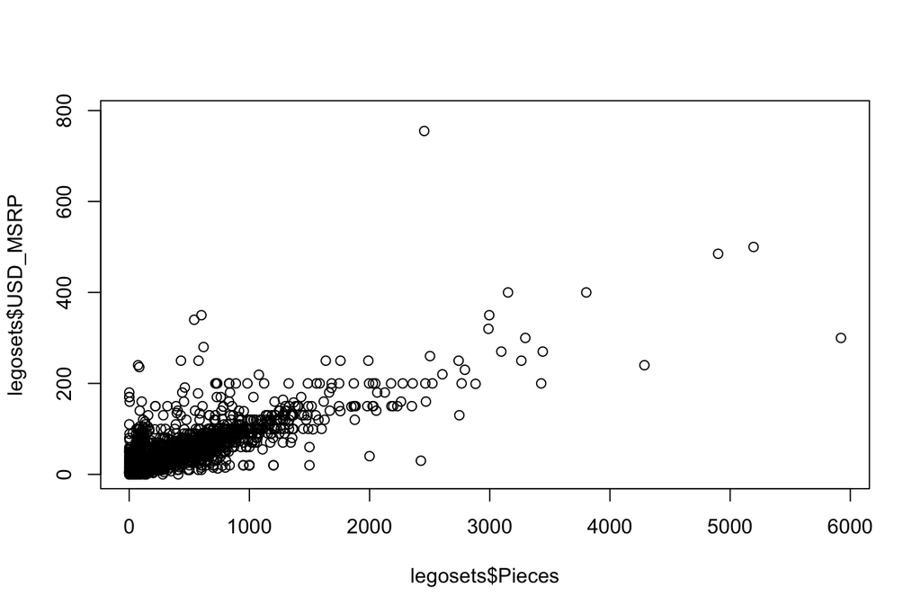

```r
plot(legosets$Pieces, legosets$USD_MSRP)
```

## Examining Possible Outliers (expensive sets)

```r
legosets[which(legosets$USD_MSRP >= 400),]
```

```
##      Item_Number                                   Name Year        Theme
## 901      2000430             Identity and Landscape Kit 2013 Serious Play
## 902      2000431                        Connections Kit 2013 Serious Play
## 2050     2000409                 Window Exploration Bag 2010 Serious Play
## 2852       10179 Ultimate Collector's Millennium Falcon 2007    Star Wars
##                       Subtheme Pieces Minifigures
## 901                                NA           6
## 902                              2455          NA
## 2050                             4900          NA
## 2852 Ultimate Collector Series   5195           5
##                                                 Image_URL GBP_MSRP USD_MSRP
## 901  http://images.brickset.com/sets/images/2000430-1.jpg   509.99   789.99
## 902  http://images.brickset.com/sets/images/2000431-1.jpg   490.18   754.99
## 2050 http://images.brickset.com/sets/images/2000409-1.jpg   314.99   484.99
## 2852   http://images.brickset.com/sets/images/10179-1.jpg   342.49   499.99
##      CAD_MSRP EUR_MSRP     Packaging  Availability
## 901    789.99   699.99 Not specified Not specified
## 902    754.99   559.99 Not specified Not specified
## 2050   484.99   359.99 Not specified Not specified
## 2852       NA       NA Not specified Not specified
```

## Examining Possible Outliers (big sets)

```r
legosets[which(legosets$Pieces >= 4000),]
```

```
##      Item_Number                                   Name Year           Theme
## 2047       10214                           Tower Bridge 2010 Advanced Models
## 2050     2000409                 Window Exploration Bag 2010    Serious Play
## 2628       10189                              Taj Mahal 2008 Advanced Models
## 2852       10179 Ultimate Collector's Millennium Falcon 2007       Star Wars
##                       Subtheme Pieces Minifigures
## 2047                 Buildings   4287          NA
## 2050                             4900          NA
## 2628                 Buildings   5922          NA
## 2852 Ultimate Collector Series   5195           5
##                                                 Image_URL GBP_MSRP USD_MSRP
## 2047   http://images.brickset.com/sets/images/10214-1.jpg   209.99   239.99
## 2050 http://images.brickset.com/sets/images/2000409-1.jpg   314.99   484.99
## 2628   http://images.brickset.com/sets/images/10189-1.jpg   199.99   299.99
## 2852   http://images.brickset.com/sets/images/10179-1.jpg   342.49   499.99
##      CAD_MSRP EUR_MSRP     Packaging     Availability
## 2047   299.99   219.99           Box Retail - limited
## 2050   484.99   359.99 Not specified    Not specified
## 2628   399.99       NA           Box Retail - limited
## 2852       NA       NA Not specified    Not specified
```

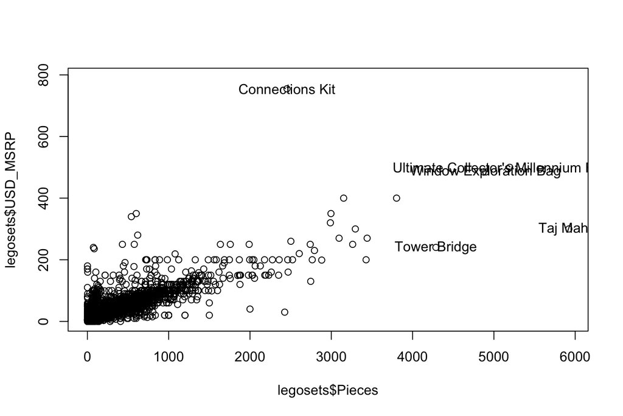

```r
plot(legosets$Pieces, legosets$USD_MSRP)
bigAndExpensive <- legosets[which(legosets$Pieces >= 4000 | legosets$USD_MSRP >= 400),]
text(bigAndExpensive$Pieces, bigAndExpensive$USD_MSRP, labels=bigAndExpensive$Name)
```

## Pie Charts

There is only one pie chart in *OpenIntro Statistics* (Diez, Barr, & Çetinkaya-Rundel, 2015, p. 48). Consider the following three pie charts that represent the preference of five different colors. Is there a difference between the three pie charts? This is probably a difficult to answer.

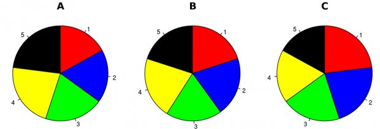

## Pie Charts

There is only one pie chart in *OpenIntro Statistics* (Diez, Barr, & Çetinkaya-Rundel, 2015, p. 48). Consider the following three pie charts that represent the preference of five different colors. Is there a difference between the three pie charts? This is probably a difficult to answer.

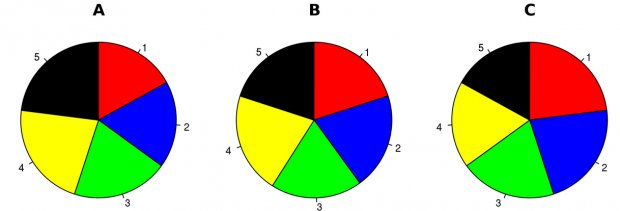

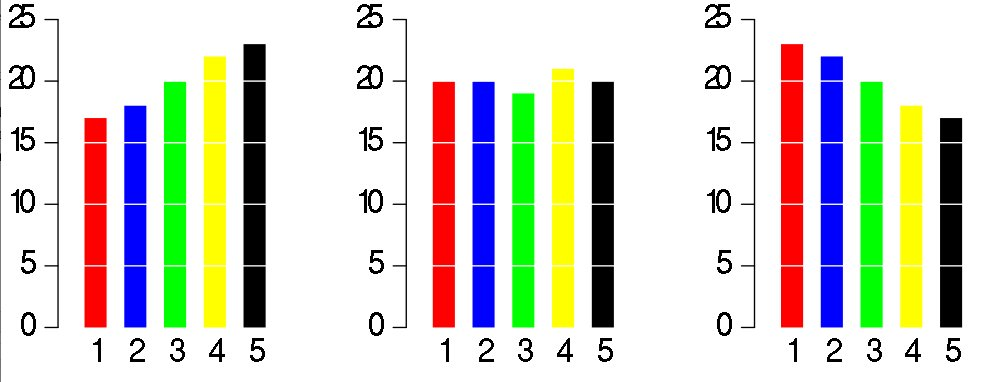

Source: https://en.wikipedia.org/wiki/Pie_chart.

## Just say NO to pie charts!

> “There is no data that can be displayed in a pie chart that cannot better be displayed in some other type of chart”

> John Tukey

## `ggplot2`

- `ggplot2` is an R package that provides an alternative framework based upon Wilkinson’s (2005) Grammar of Graphics.
- `ggplot2` is, in general, more flexible for creating “prettier” and complex plots.
- Works by creating layers of different types of objects/geometries (i.e. bars, points, lines, polygons, etc.) `ggplot2` has at least three ways of creating plots:
  1. `qplot`
  2. `ggplot(...) + geom_XXX(...) + ...`
  3. `ggplot(...) + layer(...)`
- We will focus only on the second.

## First Example

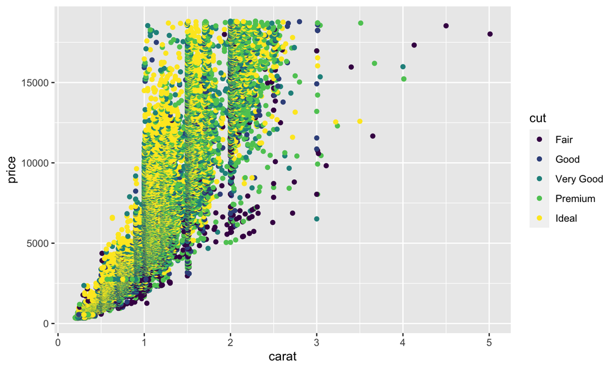

```r
library(ggplot2)
data(diamonds)
ggplot(diamonds, aes(x=carat, y=price, color=cut)) + geom_point()
```

## Parts of a `ggplot2` Statement

- Data  
  `ggplot(myDataFrame, aes(x=x, y=y)`
- Layers  
  `geom_point()`, `geom_histogram()`
- Facets  
  `facet_wrap(~ cut)`, `facet_grid(~ cut)`
- Scales  
  `scale_y_log10()`
- Other options  
  `ggtitle('my title')`, `ylim(c(0, 10000))`, `xlab('x-axis label')`

## Lots of geoms

```r
ls('package:ggplot2')[grep('geom_', ls('package:ggplot2'))]
```

```
##  [1] "geom_abline"            "geom_area"              "geom_bar"
##  [4] "geom_bin2d"             "geom_blank"             "geom_boxplot"
##  [7] "geom_col"               "geom_contour"           "geom_contour_filled"
## [10] "geom_count"             "geom_crossbar"          "geom_curve"
## [13] "geom_density"           "geom_density_2d"        "geom_density_2d_filled"
## [16] "geom_density2d"         "geom_density2d_filled"  "geom_dotplot"
## [19] "geom_errorbar"          "geom_errorbarh"         "geom_freqpoly"
## [22] "geom_function"          "geom_hex"               "geom_histogram"
## [25] "geom_hline"             "geom_jitter"            "geom_label"
## [28] "geom_line"              "geom_linerange"         "geom_map"
## [31] "geom_path"              "geom_point"             "geom_pointrange"
## [34] "geom_polygon"           "geom_qq"                "geom_qq_line"
## [37] "geom_quantile"          "geom_raster"            "geom_rect"
## [40] "geom_ribbon"            "geom_rug"               "geom_segment"
## [43] "geom_sf"                "geom_sf_label"          "geom_sf_text"
## [46] "geom_smooth"            "geom_spoke"             "geom_step"
## [49] "geom_text"              "geom_tile"              "geom_violin"
## [52] "geom_vline"             "update_geom_defaults"
```

## Scatterplot Revisited

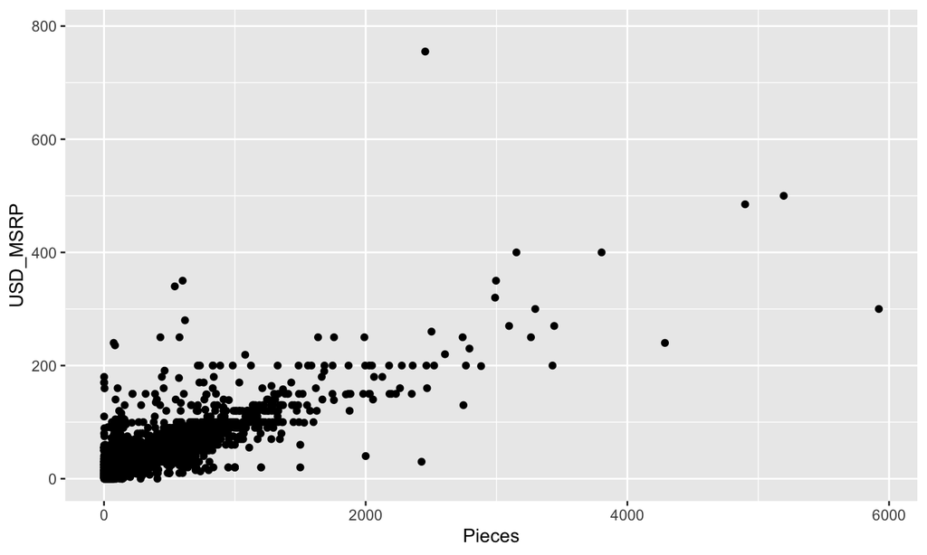

```r
ggplot(legosets, aes(x=Pieces, y=USD_MSRP)) + geom_point()
```

## Scatterplot Revisited (cont.)

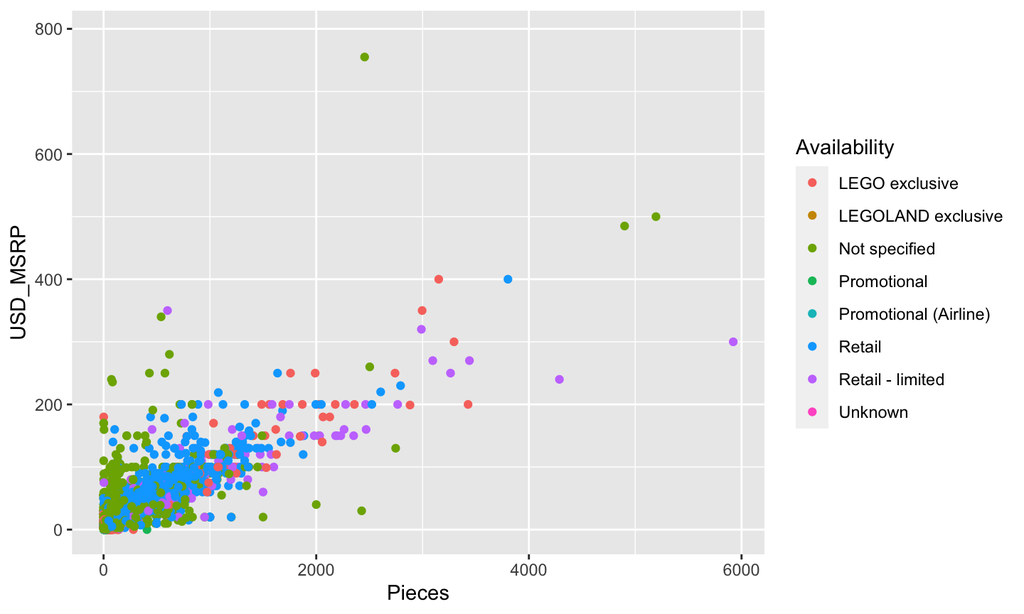

```r
ggplot(legosets, aes(x=Pieces, y=USD_MSRP, color=Availability)) + geom_point()
```

## Scatterplot Revisited (cont.)

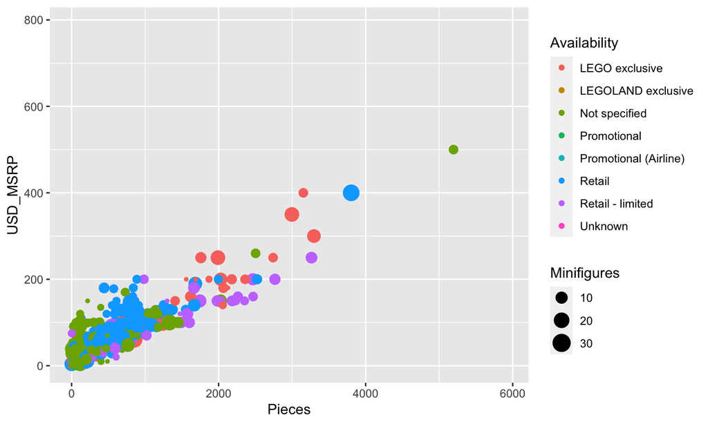

```r
ggplot(legosets, aes(x=Pieces, y=USD_MSRP, size=Minifigures, color=Availability)) + geom_point()
```

## Scatterplot Revisited (cont.)

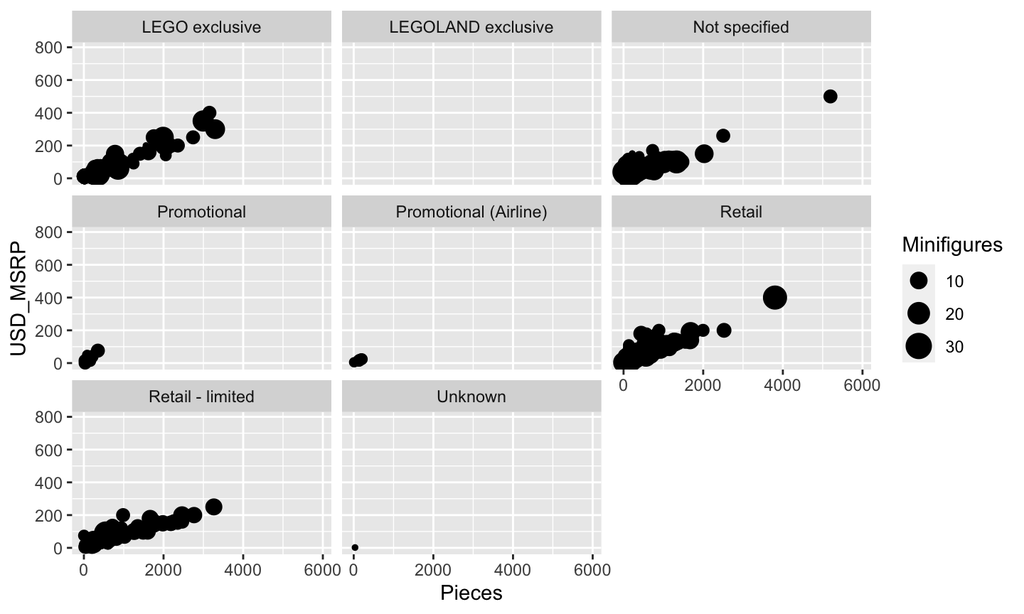

```r
ggplot(legosets, aes(x=Pieces, y=USD_MSRP, size=Minifigures)) + geom_point() + facet_wrap(~ Availability)
```

## Boxplots Revisited

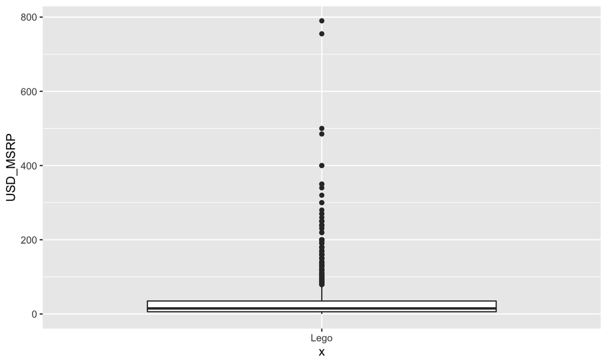

```r
ggplot(legosets, aes(x='Lego', y=USD_MSRP)) + geom_boxplot()
```

## Boxplots Revisited (cont.)

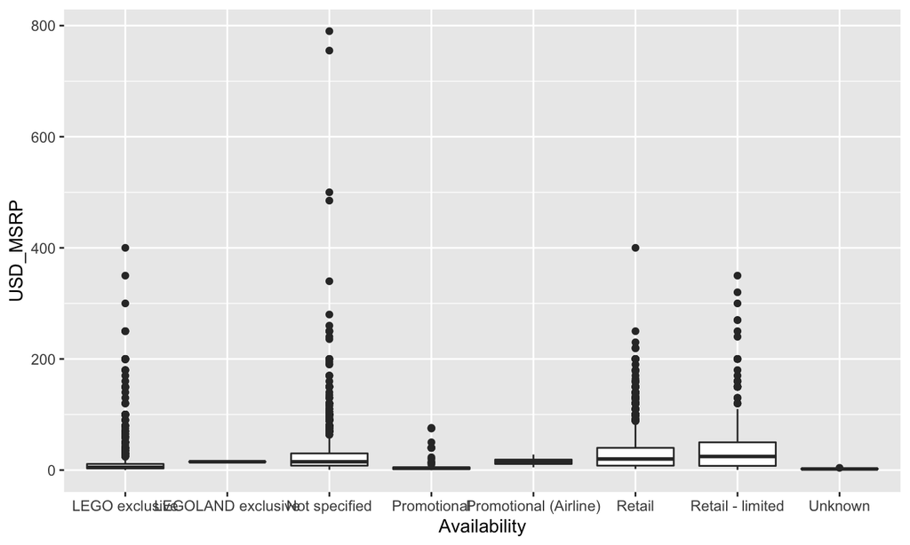

```r
ggplot(legosets, aes(x=Availability, y=USD_MSRP)) + geom_boxplot()
```

## Boxplots Revisited (cont.)

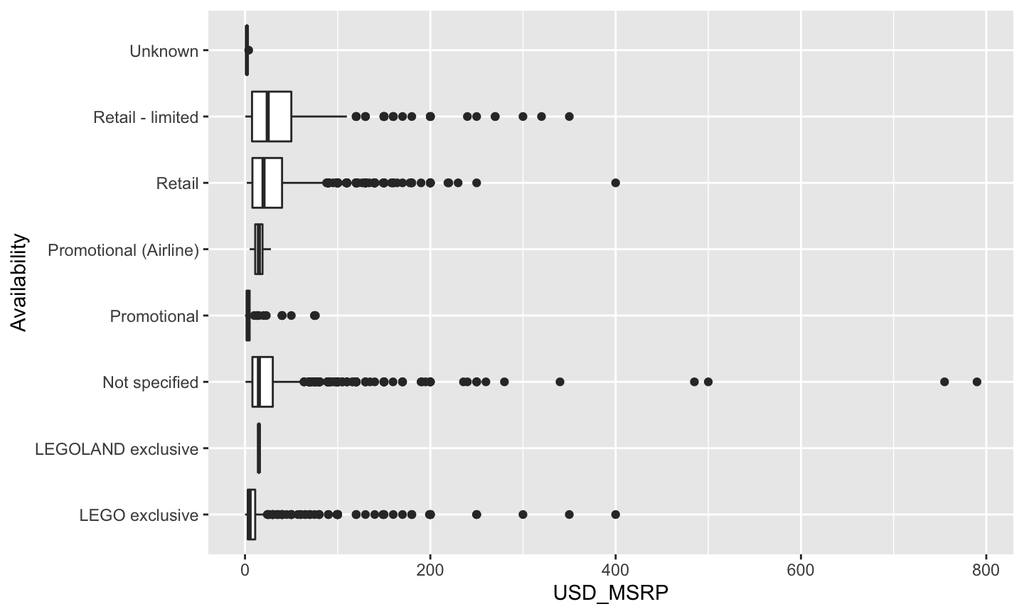

```r
ggplot(legosets, aes(x=Availability, y=USD_MSRP)) + geom_boxplot() + coord_flip()
```

## Likert Scales

Likert scales are a type of questionaire where respondents are asked to rate items on scales usually ranging from four to seven levels (e.g. strongly disagree to strongly agree).

```r
library(likert)
library(reshape)
data(pisaitems)
items24 <- pisaitems[,substr(names(pisaitems), 1,5) == 'ST24Q']
items24 <- rename(items24, c(
            ST24Q01="I read only if I have to.",
            ST24Q02="Reading is one of my favorite hobbies.",
            ST24Q03="I like talking about books with other people.",
            ST24Q04="I find it hard to finish books.",
            ST24Q05="I feel happy if I receive a book as a present.",
            ST24Q06="For me, reading is a waste of time.",
            ST24Q07="I enjoy going to a bookstore or a library.",
            ST24Q08="I read only to get information that I need.",
            ST24Q09="I cannot sit still and read for more than a few minutes.",
            ST24Q10="I like to express my opinions about books I have read.",
            ST24Q11="I like to exchange books with my friends."))
```

## `likert` R Package

```r
l24 <- likert(items24)
summary(l24)
```

```
##                                                        Item      low neutral
## 10   I like to express my opinions about books I have read. 41.07516       0
## 5            I feel happy if I receive a book as a present. 46.93475       0
## 8               I read only to get information that I need. 50.39874       0
## 7                I enjoy going to a bookstore or a library. 51.21231       0
## 3             I like talking about books with other people. 54.99129       0
## 11                I like to exchange books with my friends. 55.54115       0
## 2                    Reading is one of my favorite hobbies. 56.64470       0
## 1                                 I read only if I have to. 58.72868       0
## 4                           I find it hard to finish books. 65.35125       0
## 9  I cannot sit still and read for more than a few minutes. 76.24524       0
## 6                       For me, reading is a waste of time. 82.88729       0
##        high     mean        sd
## 10 58.92484 2.604913 0.9009968
## 5  53.06525 2.466751 0.9446590
## 8  49.60126 2.484616 0.9089688
## 7  48.78769 2.428508 0.9164136
## 3  45.00871 2.328049 0.9090326
## 11 44.45885 2.343193 0.9609234
## 2  43.35530 2.344530 0.9277495
## 1  41.27132 2.291811 0.9369023
## 4  34.64875 2.178299 0.8991628
## 9  23.75476 1.974736 0.8793028
## 6  17.11271 1.810093 0.8611554
```

## `likert` Plots

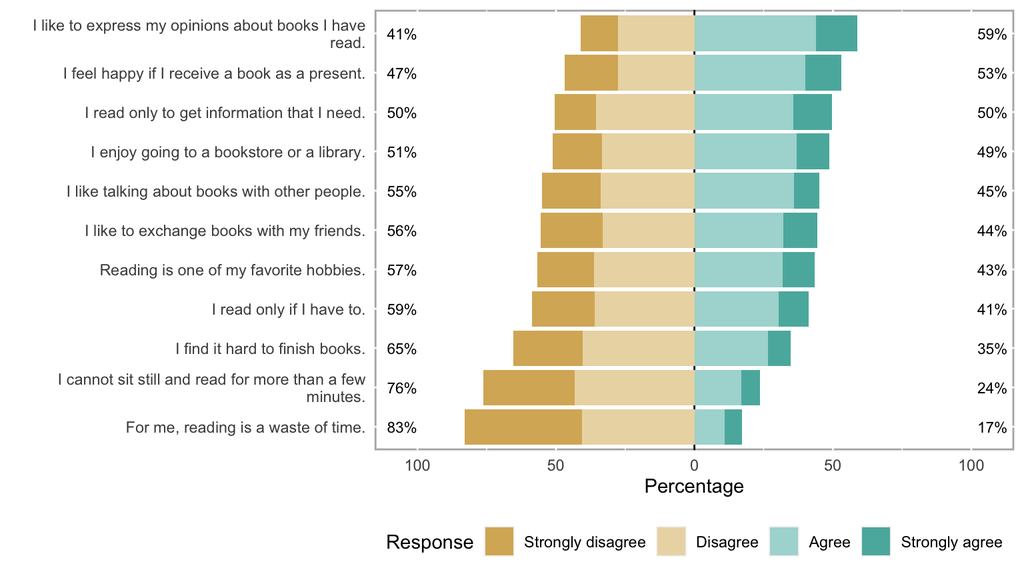

```r
plot(l24)
```

## `likert` Plots

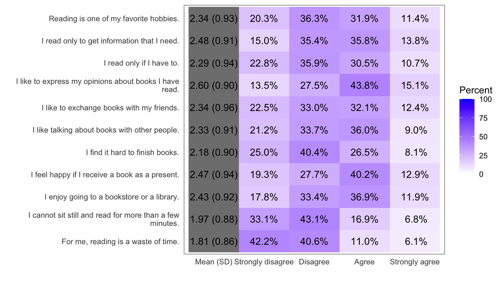

```r
plot(l24, type='heat')
```

## `likert` Plots

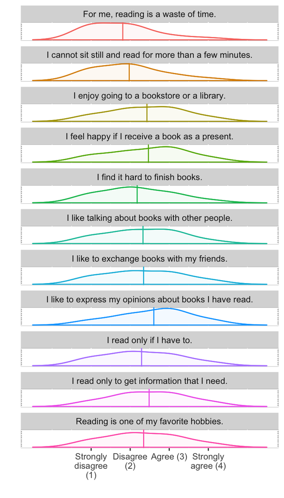

```r
plot(l24, type='density')
```

## Dual Scales

Some problems<sup>1</sup>:

This example looks at the relationship between NZ dollar exchange rate and trade weighted index.

```r
library(DATA606)
shiny_demo('DualScales', package='DATA606')
```

My advise:

- Avoid using them. You can usually do better with other plot types.
- When necessary (or compelled) to use them, rescale (using z-scores)

<sup>1</sup> http://blog.revolutionanalytics.com/2016/08/dual-axis-time-series.html <sup>2</sup> http://ellisp.github.io/blog/2016/08/18/dualaxes